# Predicción del rating de Las aplicaciones en Google Play Store

Reto DataSource

[Edimer (Sidereus)](https://edimer.github.io/)

- [Sitio oficial del reto en DataSource.](https://www.datasource.ai/es/home/data-science-competitions-for-startups/prediciendo-el-rating-de-las-aplicaciones-en-google-play-store)

# Metodología

- Las siguientes imágenes fueron tomadas del libro [Tidy Modeling with R](https://xgboost.readthedocs.io/en/latest/parameter.html) de [Max Kuhn](https://github.com/topepo) y [Julia Silge.](https://github.com/juliasilge)

## Marco General

[figure not shown]

## Estrategia de Validación

- La siguiente imagen fue tomada de [tidymodels.org](https://www.tidymodels.org/start/case-study/) e ilustra la estrategia de evaluación de modelos que adopté.

[figure not shown]

## Fases del Modelado

[figure not shown]

## Libros

### *Tidy Modeling with R*

- Consultar libro [aquí](https://www.tmwr.org/)

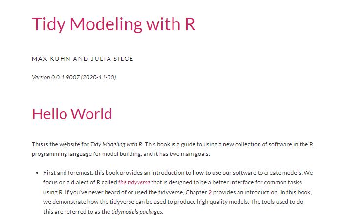

### *Applied Predictive Modeling*

- Consultar el libro [aquí.](http://appliedpredictivemodeling.com/)

[figure not shown]

### *Feature Engineering and Selection A Practical Approach for Predictive Models*

- Consultar libro [aquí.](http://www.feat.engineering/)

[figure not shown]

# Variables

# Datos

```r
# Cargando datos
library(tidyverse)
load("../data/train_FE1.Rdata")
load("../data/test_FE1.Rdata")
sampleSub <- read_csv("../data/sample_submission.csv")
head(new_train1)
```

| App | Category | Rating | Reviews | Type | content_rating | new_genres | date_update | new_day | new_year | size_kb | new_installs | new_price | new_month_num | new_version | new_subversion | min_android | letters_app | words_app | rate_reviews_install | rate_version_subversion | rate_reviews_size | rate_installs_size | mean_reviews_category | mean_reviews_genres |
| --- | --- | --- | --- | --- | --- | --- | --- | --- | --- | --- | --- | --- | --- | --- | --- | --- | --- | --- | --- | --- | --- | --- | --- | --- |
| GPS Status & Toolbox | Travel_and_local | 1 | 149723 | Free | Everyone | Travel & Local | 2018-06-13 | 13 | 2018 | 4100 | 1e+07 | 0.00 | 6 | 8 | 1 | 4.0 | 20 | 4 | 0.0149723 | 8.0000000 | 3.651780e+01 | 2439.0243902 | 160462.49 | 160462.49 |
| Fish\|Hunt FL | Lifestyle | 0 | 853 | Free | Everyone | Lifestyle | 2018-03-22 | 22 | 2018 | 34000 | 1e+05 | 0.00 | 3 | 3 | 2 | 4.1 | 12 | 2 | 0.0085300 | 1.5000000 | 2.508824e-02 | 2.9411765 | 38441.68 | 38441.68 |
| Allrecipes Dinner Spinner | Food_and_drink | 1 | 61881 | Free | Everyone | Food & Drink | 2018-04-10 | 10 | 2018 | NA | 5e+06 | 0.00 | 4 | NA | NA | NA | 25 | 3 | 0.0123762 | NA | NA | NA | 61498.30 | 61498.30 |
| Don't touch my phone | Tools | 0 | 21943 | Free | Everyone | Tools | 2016-10-19 | 19 | 2016 | 2300 | 5e+06 | 0.00 | 10 | NA | NA | 2.3 | 20 | 4 | 0.0043886 | NA | 9.540435e+00 | 2173.9130435 | 300009.70 | 300009.70 |
| BM SPM Practice | Family | 1 | 6 | Free | Everyone | Education | 2018-01-24 | 24 | 2018 | 9200 | 1e+03 | 0.00 | 1 | 1 | 0 | 4.1 | 15 | 3 | 0.0060000 | 0.0000000 | 6.521739e-04 | 0.1086957 | 64330.01 | 33912.07 |
| Advanced EX for FIAT | Tools | 0 | 138 | Paid | Everyone | Tools | 2015-03-05 | 5 | 2015 | 141 | 5e+03 | 4.99 | 3 | 1 | 6 | 1.6 | 20 | 4 | 0.0276000 | 0.1666667 | 9.787234e-01 | 35.4609929 | 300009.70 | 300009.70 |

- Selecciono sólo las variables que van a ingresar al análisis.

```r
mi_train <- new_train1 %>%
  select(-c(App, date_update))

mi_test <- new_test1 %>%
  select(-c(App, date_update))
```

- Primero se garantiza que los modelos sean entrenados con las mismas variables que contiene el archivo de test (submission).

```r
library(fastDummies)
# Binarización en test
binar_train <- dummy_cols(mi_train, remove_selected_columns = TRUE)
binar_test <- dummy_cols(mi_test, remove_selected_columns = TRUE)

# Las mismas variables en train y test (submission)
variables_iguales <- c(names(binar_train)[names(binar_train) %in% names(binar_test)],
                       "Rating")

# Datos de train finales
binar_train <- binar_train[, variables_iguales]
```

# Modelos

- [Documentación Catboost](https://catboost.ai/docs/concepts/about.html)
- [Biblioteca `treesnip`](https://curso-r.github.io/treesnip/index.html)
- [Biblioteca `treesnip` (Github)](https://github.com/curso-r/treesnip)
- Preprocesamiento:
  - Binarización (previamente binarizadas).
  - Imputación a través de *knn*. Este paso se podría obviar ya que el algoritmo maneja bien los valores ausentes.
  - Como es un problema de clasificación imbalanceado, utilizo la biblioteca themis para generar clases balanceadas a través de muestreo con reemplazo (ascendnete - *upsample*).
- Pasos a seguir con *tidymodels*:
  - 0. División en *train*, *validación* y *test*
  - 1. Definir preprocesamiento
  - 2. Definir el modelo y los hiperparámetros a optimizar
  - 3. Definir la estrategia de validación del modelo
  - 4. Definir tipo de *tuning* (grid de hiperparámetros)
  - 5. Definir el frujo de trabajo (*workflow* en *tidymodels*)
  - 6. Ejecución o entrenamiento de modelos (*tuning*)
  - 7. Evaluación de modelos (gráficos con métricas de error)
  - 8. Ajuste del modelo final
  - 9. Predicciones finales

# Etapas del modelo

## Etapa 0 - Split

```r
# Tidymodels
library(tidymodels)

# Train-Test
set.seed(2020)
data_split <- initial_split(data = binar_train, prop = 0.80)
data_train <- training(data_split) %>% mutate(Rating = as.factor(Rating))
data_test <- testing(data_split) %>% mutate(Rating = as.factor(Rating))
```

## Etapa 1 - Preprocesamiento

```r
library(themis)
receta1 <- recipe(Rating ~ ., data = data_train) %>%
  step_knnimpute(all_predictors(), neighbors = 2) %>%
  step_upsample(Rating)
```

## Etapa 2 - Modelos

- [Ajuste de modelos *Catboost* y *LightGBM* con `treesnip`](https://curso-r.github.io/treesnip/articles/working-with-lightgbm-catboost.html)

```r
# Modelo Catboost
library(catboost)
library(treesnip)
mod_catb <- boost_tree(
  mode = "classification",
  mtry = tune(),
  trees = tune(),
  min_n = tune(),
  tree_depth = tune(),
  learn_rate = 0.01,
  sample_size = tune()
) %>%
  set_engine("catboost", nthread = 1)
```

## Etapa 3 - Validación

```r
set.seed(1234)
cv_config <- vfold_cv(data = data_train,
                      v = 10,
                      strata = Rating)
```

## Etapa 4 - Grid Tuning

- En este caso voy a usar máxima entropia de tamaño 100.

```r
# Hiperparámetros Modelo Catboost
set.seed(12345)
catb_params <- parameters(
  finalize(mtry(), x = data_train[, -104]),
  trees(),
  min_n(),
  tree_depth(range = c(4, 10)),
  sample_size = sample_prop()
)

catb_grid <- grid_max_entropy(catb_params,
                              size = 100)
```

## Etapa 5 - *Workflow*

```r
# Workflow Modelo LightGBM
catb_wflow <- workflow() %>%
  add_recipe(receta1) %>%
  add_model(mod_catb)
```

## Etapa 6 - *Tuning*

```r
# Dependencias
#set_dependency("boost_tree", eng = "lightgbm", "lightgbm")
#set_dependency("boost_tree", eng = "lightgbm", "treesnip")

# Tiempos
library(tictoc)
tic() # Tiempo 0

#doParallel::registerDoParallel() # Inicio Paralelización
library(doMC)
registerDoMC(cores = 1)

# Tuning
catb_tuned <- tune_grid(
  object = catb_wflow,
  resamples = cv_config,
  grid = catb_grid,
  metrics = metric_set(roc_auc, f_meas),
  control = control_grid(save_pred = TRUE)
)

#doParallel::stopImplicitCluster() # Fin Paralelización

toc() # Tiempo final
```

## Etapa 7 - Evaluación de modelos

- **Mejores parámetros con f1 score:**

```r
catb_tuned %>%
  collect_metrics() %>%
  filter(.metric == "f_meas") %>%
  arrange(desc(mean))
```

| mtry | trees | min_n | tree_depth | sample_size | .metric | .estimator | mean | n | std_err | .config |
| --- | --- | --- | --- | --- | --- | --- | --- | --- | --- | --- |
| 76 | 779 | 12 | 8 | 0.8941662 | f_meas | binary | 0.5513860 | 10 | 0.0062173847 | Preprocessor1_Model074 |
| 60 | 1402 | 31 | 6 | 0.6422839 | f_meas | binary | 0.5479304 | 10 | 0.0060326560 | Preprocessor1_Model056 |
| 42 | 1339 | 19 | 8 | 0.9831209 | f_meas | binary | 0.5478820 | 10 | 0.0055644015 | Preprocessor1_Model039 |
| 90 | 1053 | 38 | 9 | 0.9667214 | f_meas | binary | 0.5472671 | 10 | 0.0054166430 | Preprocessor1_Model089 |
| 45 | 1924 | 24 | 5 | 0.9791172 | f_meas | binary | 0.5467410 | 10 | 0.0040809915 | Preprocessor1_Model042 |
| 8 | 1623 | 7 | 9 | 0.9967710 | f_meas | binary | 0.5466647 | 10 | 0.0076438754 | Preprocessor1_Model010 |
| 28 | 1189 | 20 | 8 | 0.3855489 | f_meas | binary | 0.5466502 | 10 | 0.0050708312 | Preprocessor1_Model024 |
| 59 | 1897 | 25 | 5 | 0.5825228 | f_meas | binary | 0.5465054 | 10 | 0.0045849369 | Preprocessor1_Model055 |
| 35 | 416 | 16 | 10 | 0.9134997 | f_meas | binary | 0.5464432 | 10 | 0.0065097427 | Preprocessor1_Model033 |
| 68 | 1452 | 31 | 7 | 0.4759255 | f_meas | binary | 0.5462120 | 10 | 0.0062523760 | Preprocessor1_Model065 |

[output cut: 90 more lines]

```r
show_best(catb_tuned, metric = "f_meas")
```

| mtry | trees | min_n | tree_depth | sample_size | .metric | .estimator | mean | n | std_err | .config |
| --- | --- | --- | --- | --- | --- | --- | --- | --- | --- | --- |
| 76 | 779 | 12 | 8 | 0.8941662 | f_meas | binary | 0.5513860 | 10 | 0.006217385 | Preprocessor1_Model074 |
| 60 | 1402 | 31 | 6 | 0.6422839 | f_meas | binary | 0.5479304 | 10 | 0.006032656 | Preprocessor1_Model056 |
| 42 | 1339 | 19 | 8 | 0.9831209 | f_meas | binary | 0.5478820 | 10 | 0.005564402 | Preprocessor1_Model039 |
| 90 | 1053 | 38 | 9 | 0.9667214 | f_meas | binary | 0.5472671 | 10 | 0.005416643 | Preprocessor1_Model089 |
| 45 | 1924 | 24 | 5 | 0.9791172 | f_meas | binary | 0.5467410 | 10 | 0.004080991 | Preprocessor1_Model042 |

```r
select_best(catb_tuned, metric = "f_meas")
```

| mtry | trees | min_n | tree_depth | sample_size | .config |
| --- | --- | --- | --- | --- | --- |
| 76 | 779 | 12 | 8 | 0.8941662 | Preprocessor1_Model074 |

- **Mejores parámetros con roc_auc:**

```r
catb_tuned %>%
  collect_metrics() %>%
  filter(.metric == "roc_auc") %>%
  arrange(desc(mean))
```

| mtry | trees | min_n | tree_depth | sample_size | .metric | .estimator | mean | n | std_err | .config |
| --- | --- | --- | --- | --- | --- | --- | --- | --- | --- | --- |
| 23 | 1429 | 13 | 6 | 0.2510158 | roc_auc | binary | 0.7839425 | 10 | 0.006465301 | Preprocessor1_Model021 |
| 76 | 779 | 12 | 8 | 0.8941662 | roc_auc | binary | 0.7838169 | 10 | 0.007265883 | Preprocessor1_Model074 |
| 8 | 1180 | 29 | 10 | 0.3989889 | roc_auc | binary | 0.7837721 | 10 | 0.006656694 | Preprocessor1_Model011 |
| 60 | 1402 | 31 | 6 | 0.6422839 | roc_auc | binary | 0.7835942 | 10 | 0.007073301 | Preprocessor1_Model056 |
| 48 | 910 | 10 | 9 | 0.4639225 | roc_auc | binary | 0.7835000 | 10 | 0.007241539 | Preprocessor1_Model043 |
| 81 | 758 | 31 | 9 | 0.9319504 | roc_auc | binary | 0.7832300 | 10 | 0.007425481 | Preprocessor1_Model079 |
| 35 | 416 | 16 | 10 | 0.9134997 | roc_auc | binary | 0.7828573 | 10 | 0.007043162 | Preprocessor1_Model033 |
| 10 | 1139 | 27 | 8 | 0.8484561 | roc_auc | binary | 0.7828387 | 10 | 0.006407077 | Preprocessor1_Model012 |
| 73 | 1015 | 8 | 7 | 0.4379108 | roc_auc | binary | 0.7825599 | 10 | 0.006855550 | Preprocessor1_Model069 |
| 53 | 329 | 29 | 9 | 0.8283601 | roc_auc | binary | 0.7825243 | 10 | 0.006519115 | Preprocessor1_Model049 |

[output cut: 90 more lines]

```r
show_best(catb_tuned, metric = "roc_auc")
```

| mtry | trees | min_n | tree_depth | sample_size | .metric | .estimator | mean | n | std_err | .config |
| --- | --- | --- | --- | --- | --- | --- | --- | --- | --- | --- |
| 23 | 1429 | 13 | 6 | 0.2510158 | roc_auc | binary | 0.7839425 | 10 | 0.006465301 | Preprocessor1_Model021 |
| 76 | 779 | 12 | 8 | 0.8941662 | roc_auc | binary | 0.7838169 | 10 | 0.007265883 | Preprocessor1_Model074 |
| 8 | 1180 | 29 | 10 | 0.3989889 | roc_auc | binary | 0.7837721 | 10 | 0.006656694 | Preprocessor1_Model011 |
| 60 | 1402 | 31 | 6 | 0.6422839 | roc_auc | binary | 0.7835942 | 10 | 0.007073301 | Preprocessor1_Model056 |
| 48 | 910 | 10 | 9 | 0.4639225 | roc_auc | binary | 0.7835000 | 10 | 0.007241539 | Preprocessor1_Model043 |

```r
select_best(catb_tuned, metric = "roc_auc")
```

| mtry | trees | min_n | tree_depth | sample_size | .config |
| --- | --- | --- | --- | --- | --- |
| 23 | 1429 | 13 | 6 | 0.2510158 | Preprocessor1_Model021 |

- En este caso los mejores modelos con ambas métricas resultaron ser diferentes. Utilizo predicciones con ambos.

### Hiperparámetros ROC-AUC

- **Tabla resumen:**

```r
catb_tuned %>%
  collect_metrics() %>%
  filter(.metric == "roc_auc") %>%
  arrange(desc(mean))
```

| mtry | trees | min_n | tree_depth | sample_size | .metric | .estimator | mean | n | std_err | .config |
| --- | --- | --- | --- | --- | --- | --- | --- | --- | --- | --- |
| 23 | 1429 | 13 | 6 | 0.2510158 | roc_auc | binary | 0.7839425 | 10 | 0.006465301 | Preprocessor1_Model021 |
| 76 | 779 | 12 | 8 | 0.8941662 | roc_auc | binary | 0.7838169 | 10 | 0.007265883 | Preprocessor1_Model074 |
| 8 | 1180 | 29 | 10 | 0.3989889 | roc_auc | binary | 0.7837721 | 10 | 0.006656694 | Preprocessor1_Model011 |
| 60 | 1402 | 31 | 6 | 0.6422839 | roc_auc | binary | 0.7835942 | 10 | 0.007073301 | Preprocessor1_Model056 |
| 48 | 910 | 10 | 9 | 0.4639225 | roc_auc | binary | 0.7835000 | 10 | 0.007241539 | Preprocessor1_Model043 |
| 81 | 758 | 31 | 9 | 0.9319504 | roc_auc | binary | 0.7832300 | 10 | 0.007425481 | Preprocessor1_Model079 |
| 35 | 416 | 16 | 10 | 0.9134997 | roc_auc | binary | 0.7828573 | 10 | 0.007043162 | Preprocessor1_Model033 |
| 10 | 1139 | 27 | 8 | 0.8484561 | roc_auc | binary | 0.7828387 | 10 | 0.006407077 | Preprocessor1_Model012 |
| 73 | 1015 | 8 | 7 | 0.4379108 | roc_auc | binary | 0.7825599 | 10 | 0.006855550 | Preprocessor1_Model069 |
| 53 | 329 | 29 | 9 | 0.8283601 | roc_auc | binary | 0.7825243 | 10 | 0.006519115 | Preprocessor1_Model049 |

[output cut: 90 more lines]

- **Hiperparámetros:**

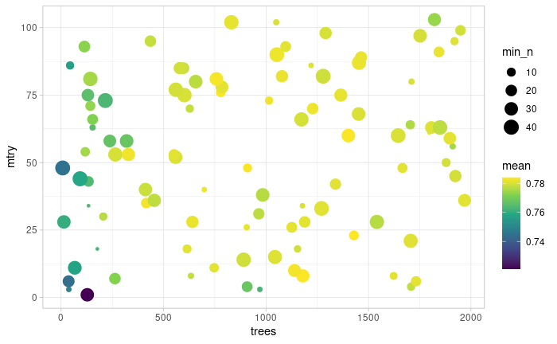

```r
catb_tuned %>%
  collect_metrics() %>%
  filter(.metric == "roc_auc") %>%
  ggplot(aes(x = trees, y = mtry, size = min_n, color = mean)) +
  geom_point() +
  theme_light() +
  scale_color_viridis_c()
```

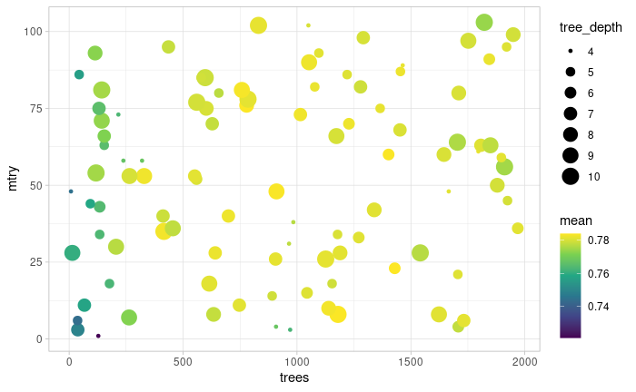

```r
catb_tuned %>%
  collect_metrics() %>%
  filter(.metric == "roc_auc") %>%
  ggplot(aes(x = trees, y = mtry, size = tree_depth, color = mean)) +
  geom_point() +
  theme_light() +
  scale_color_viridis_c()
```

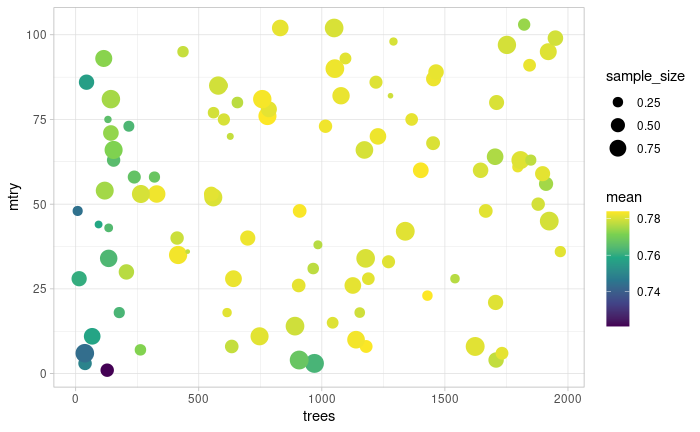

```r
catb_tuned %>%
  collect_metrics() %>%
  filter(.metric == "roc_auc") %>%
  ggplot(aes(x = trees, y = mtry, size = sample_size, color = mean)) +
  geom_point() +
  theme_light() +
  scale_color_viridis_c()
```

### Desemepeño

- **Ajuste con mejores hiperparámetros:**

```r
# Mejores parámetros
mejor_roc <- select_best(catb_tuned, metric = "roc_auc")

# Finalizando workflow
modelo_final1 <- finalize_workflow(
  x = catb_wflow,
  parameters = mejor_roc
)

modelo_final1_fit <- modelo_final1 %>%
  fit(data = data_train)
```

- **Predicciones en Train:**

```r
# Clases predichas en train
clases_train <- modelo_final1_fit %>%
  predict(new_data = data_train, type = "class")

# Probabilidades predichas en train
probs_train <- modelo_final1_fit %>%
  predict(new_data = data_train, type = "prob")

# Reales, clases predichas y probabilidades predichas
predichos_train <- bind_cols(clases_train, probs_train) %>%
  mutate(real = data_train$Rating)

head(predichos_train)
```

| .pred_class | .pred_0 | .pred_1 | real |
| --- | --- | --- | --- |
| 1 | 0.3178499 | 0.6821501 | 1 |
| 0 | 0.8777168 | 0.1222832 | 0 |
| 0 | 0.4062225 | 0.5937775 | 1 |
| 0 | 0.7867494 | 0.2132506 | 0 |
| 0 | 0.4957685 | 0.5042315 | 1 |
| 0 | 0.7781807 | 0.2218193 | 0 |

- **Matriz de confusión en Train:**

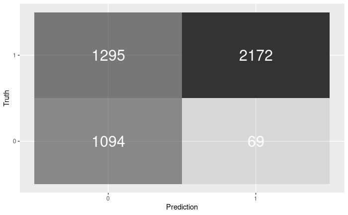

```r
predichos_train %>%
  conf_mat(real, .pred_class) %>%
  pluck(1) %>%
  as_tibble() %>%
  ggplot(aes(x = Prediction, y = Truth, alpha = n)) +
  geom_tile(show.legend = FALSE) +
  geom_text(aes(label = n), colour = "white", alpha = 1, size = 8)
```

- **Precisión en Train:**

```r
predichos_train %>%
  accuracy(real, .pred_class)
```

| .metric | .estimator | .estimate |
| --- | --- | --- |
| accuracy | binary | 0.7053996 |

- **Curva ROC:**

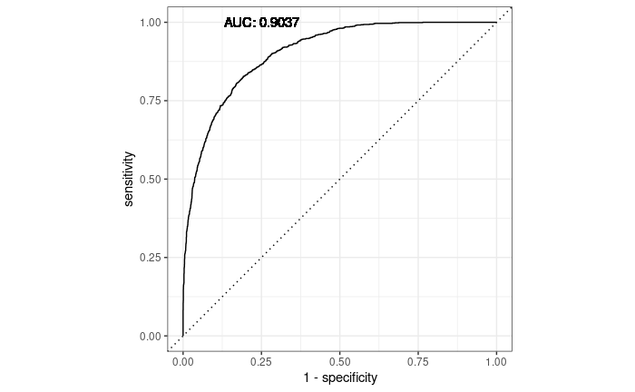

```r
predichos_train %>%
  roc_curve(real, .pred_0) %>%
  autoplot() +
  geom_text(aes(
    x = 0.25,
    y = 1,
    label = paste0(
      "AUC: ",
      predichos_train %>%
        roc_auc(real, .pred_0) %>%
        pull(.estimate) %>%
        round(digits = 4)
    )
  ))
```

- **Predicciones en Validación:**

```r
# Clases predichas en train
clases_val <- modelo_final1_fit %>%
  predict(new_data = data_test, type = "class")

# Probabilidades predichas en train
probs_val <- modelo_final1_fit %>%
  predict(new_data = data_test, type = "prob")

# Reales, clases predichas y probabilidades predichas
predichos_val <- bind_cols(clases_val, probs_val) %>%
  mutate(real = data_test$Rating)

head(predichos_val)
```

| .pred_class | .pred_0 | .pred_1 | real |
| --- | --- | --- | --- |
| 0 | 0.51191019 | 0.4880898 | 1 |
| 0 | 0.67346960 | 0.3265304 | 1 |
| 1 | 0.19417896 | 0.8058210 | 1 |
| 1 | 0.27530872 | 0.7246913 | 1 |
| 1 | 0.29340427 | 0.7065957 | 1 |
| 1 | 0.04916428 | 0.9508357 | 1 |

- **Matriz de confusión en Validación:**

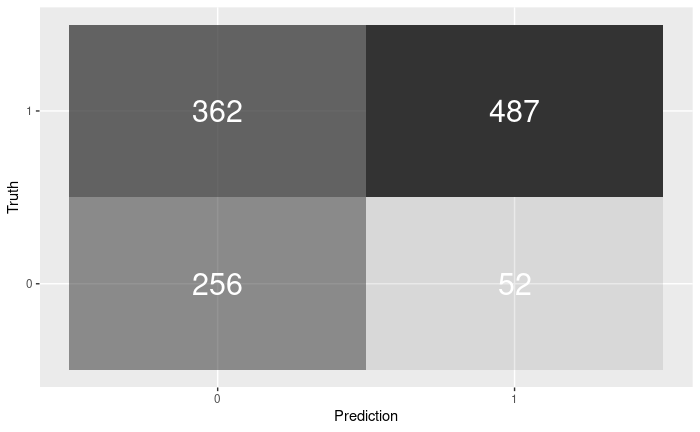

```r
predichos_val%>%
  conf_mat(real, .pred_class) %>%
  pluck(1) %>%
  as_tibble() %>%
  ggplot(aes(x = Prediction, y = Truth, alpha = n)) +
  geom_tile(show.legend = FALSE) +
  geom_text(aes(label = n), colour = "white", alpha = 1, size = 8)
```

```r
predichos_val %>%
  accuracy(real, .pred_class)
```

| .metric | .estimator | .estimate |
| --- | --- | --- |
| accuracy | binary | 0.642178 |

- **Curva ROC:**

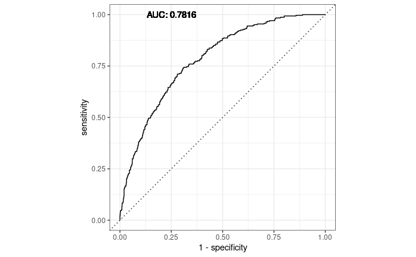

```r
predichos_val %>%
  roc_curve(real, .pred_0) %>%
  autoplot() +
  geom_text(aes(
    x = 0.25,
    y = 1,
    label = paste0(
      "AUC: ",
      predichos_val %>%
        roc_auc(real, .pred_0) %>%
        pull(.estimate) %>%
        round(digits = 4)
    )
  ))
```

### Hiperparámetros F1 Score

- **Tabla resumen:**

```r
catb_tuned %>%
  collect_metrics() %>%
  filter(.metric == "f_meas") %>%
  arrange(desc(mean))
```

| mtry | trees | min_n | tree_depth | sample_size | .metric | .estimator | mean | n | std_err | .config |
| --- | --- | --- | --- | --- | --- | --- | --- | --- | --- | --- |
| 76 | 779 | 12 | 8 | 0.8941662 | f_meas | binary | 0.5513860 | 10 | 0.0062173847 | Preprocessor1_Model074 |
| 60 | 1402 | 31 | 6 | 0.6422839 | f_meas | binary | 0.5479304 | 10 | 0.0060326560 | Preprocessor1_Model056 |
| 42 | 1339 | 19 | 8 | 0.9831209 | f_meas | binary | 0.5478820 | 10 | 0.0055644015 | Preprocessor1_Model039 |
| 90 | 1053 | 38 | 9 | 0.9667214 | f_meas | binary | 0.5472671 | 10 | 0.0054166430 | Preprocessor1_Model089 |
| 45 | 1924 | 24 | 5 | 0.9791172 | f_meas | binary | 0.5467410 | 10 | 0.0040809915 | Preprocessor1_Model042 |
| 8 | 1623 | 7 | 9 | 0.9967710 | f_meas | binary | 0.5466647 | 10 | 0.0076438754 | Preprocessor1_Model010 |
| 28 | 1189 | 20 | 8 | 0.3855489 | f_meas | binary | 0.5466502 | 10 | 0.0050708312 | Preprocessor1_Model024 |
| 59 | 1897 | 25 | 5 | 0.5825228 | f_meas | binary | 0.5465054 | 10 | 0.0045849369 | Preprocessor1_Model055 |
| 35 | 416 | 16 | 10 | 0.9134997 | f_meas | binary | 0.5464432 | 10 | 0.0065097427 | Preprocessor1_Model033 |
| 68 | 1452 | 31 | 7 | 0.4759255 | f_meas | binary | 0.5462120 | 10 | 0.0062523760 | Preprocessor1_Model065 |

[output cut: 90 more lines]

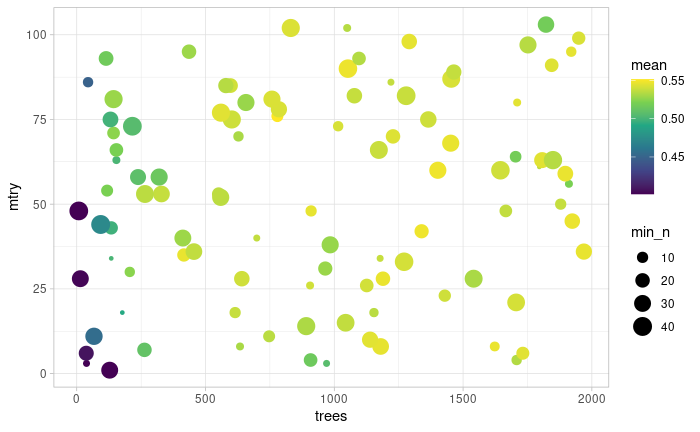

```r
catb_tuned %>%
  collect_metrics() %>%
  filter(.metric == "f_meas") %>%
  ggplot(aes(x = trees, y = mtry, size = min_n, color = mean)) +
  geom_point() +
  theme_light() +
  scale_color_viridis_c()
```

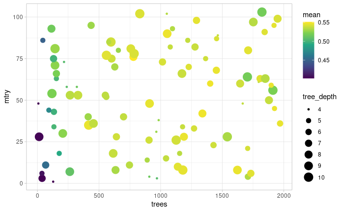

```r
catb_tuned %>%
  collect_metrics() %>%
  filter(.metric == "f_meas") %>%
  ggplot(aes(x = trees, y = mtry, size = tree_depth, color = mean)) +
  geom_point() +
  theme_light() +
  scale_color_viridis_c()
```

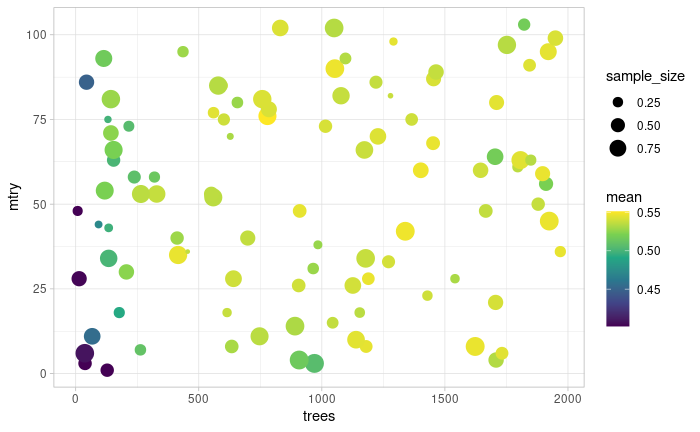

```r
catb_tuned %>%
  collect_metrics() %>%
  filter(.metric == "f_meas") %>%
  ggplot(aes(x = trees, y = mtry, size = sample_size, color = mean)) +
  geom_point() +
  theme_light() +
  scale_color_viridis_c()
```

### Desemepeño

- **Ajuste con mejores hiperparámetros:**

```r
# Mejores parámetros
mejor_f1 <- select_best(catb_tuned, metric = "f_meas")

# Finalizando workflow
modelo_final2 <- finalize_workflow(
  x = catb_wflow,
  parameters = mejor_f1
)

modelo_final2_fit <- modelo_final2 %>%
  fit(data = data_train)
```

- **Predicciones en Train:**

```r
# Clases predichas en train
clases_train2 <- modelo_final2_fit %>%
  predict(new_data = data_train, type = "class")

# Probabilidades predichas en train
probs_train2 <- modelo_final2_fit %>%
  predict(new_data = data_train, type = "prob")

# Reales, clases predichas y probabilidades predichas
predichos_train2 <- bind_cols(clases_train2, probs_train2) %>%
  mutate(real = data_train$Rating)

head(predichos_train2)
```

| .pred_class | .pred_0 | .pred_1 | real |
| --- | --- | --- | --- |
| 1 | 0.3013843 | 0.6986157 | 1 |
| 0 | 0.8801571 | 0.1198429 | 0 |
| 0 | 0.3836831 | 0.6163169 | 1 |
| 0 | 0.8243361 | 0.1756639 | 0 |
| 0 | 0.4012657 | 0.5987343 | 1 |
| 0 | 0.8357685 | 0.1642315 | 0 |

- **Matriz de confusión en Train:**

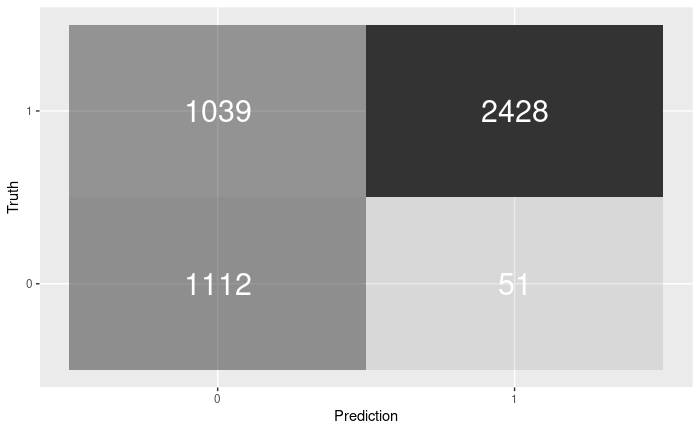

```r
predichos_train2 %>%
  conf_mat(real, .pred_class) %>%
  pluck(1) %>%
  as_tibble() %>%
  ggplot(aes(x = Prediction, y = Truth, alpha = n)) +
  geom_tile(show.legend = FALSE) +
  geom_text(aes(label = n), colour = "white", alpha = 1, size = 8)
```

- **Precisión en Train:**

```r
predichos_train2 %>%
  accuracy(real, .pred_class)
```

| .metric | .estimator | .estimate |
| --- | --- | --- |
| accuracy | binary | 0.7645788 |

- **Curva ROC:**

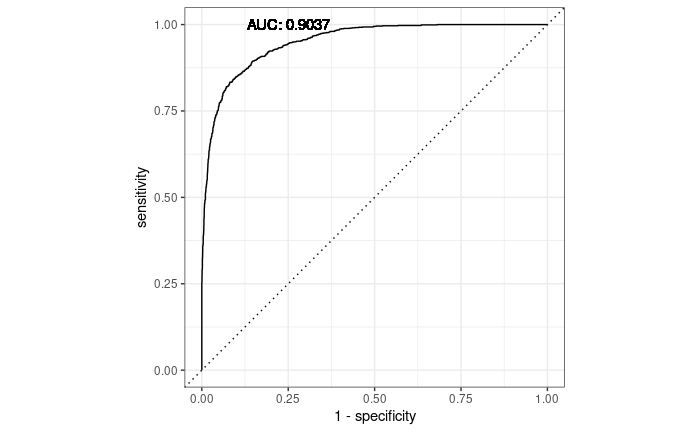

```r
predichos_train2 %>%
  roc_curve(real, .pred_0) %>%
  autoplot() +
  geom_text(aes(
    x = 0.25,
    y = 1,
    label = paste0(
      "AUC: ",
      predichos_train %>%
        roc_auc(real, .pred_0) %>%
        pull(.estimate) %>%
        round(digits = 4)
    )
  ))
```

- **Predicciones en Validación:**

```r
# Clases predichas en train
clases_val2 <- modelo_final2_fit %>%
  predict(new_data = data_test, type = "class")

# Probabilidades predichas en train
probs_val2 <- modelo_final2_fit %>%
  predict(new_data = data_test, type = "prob")

# Reales, clases predichas y probabilidades predichas
predichos_val2 <- bind_cols(clases_val2, probs_val2) %>%
  mutate(real = data_test$Rating)

head(predichos_val2)
```

| .pred_class | .pred_0 | .pred_1 | real |
| --- | --- | --- | --- |
| 0 | 0.43253997 | 0.5674600 | 1 |
| 0 | 0.65319232 | 0.3468077 | 1 |
| 1 | 0.18592026 | 0.8140797 | 1 |
| 1 | 0.25321951 | 0.7467805 | 1 |
| 1 | 0.23917605 | 0.7608240 | 1 |
| 1 | 0.03678309 | 0.9632169 | 1 |

- **Matriz de confusión en Validación:**

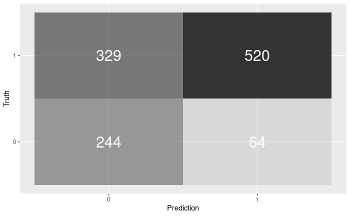

```r
predichos_val2 %>%
  conf_mat(real, .pred_class) %>%
  pluck(1) %>%
  as_tibble() %>%
  ggplot(aes(x = Prediction, y = Truth, alpha = n)) +
  geom_tile(show.legend = FALSE) +
  geom_text(aes(label = n), colour = "white", alpha = 1, size = 8)
```

```r
predichos_val2 %>%
  accuracy(real, .pred_class)
```

| .metric | .estimator | .estimate |
| --- | --- | --- |
| accuracy | binary | 0.6603284 |

- **Curva ROC:**

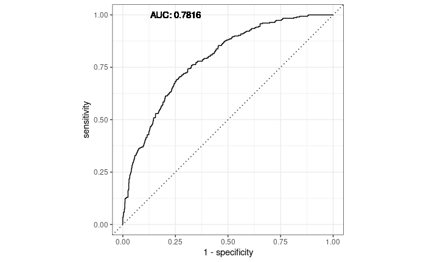

```r
predichos_val2 %>%
  roc_curve(real, .pred_0) %>%
  autoplot() +
  geom_text(aes(
    x = 0.25,
    y = 1,
    label = paste0(
      "AUC: ",
      predichos_val %>%
        roc_auc(real, .pred_0) %>%
        pull(.estimate) %>%
        round(digits = 4)
    )
  ))
```

# Modelo Final ROC

```r
# Finalizando modelación
prep_final <- prep(x = receta1)
data_final <- bake(object = prep_final,
                   new_data = binar_train %>% mutate(Rating = as.factor(Rating)))

modelo_completo <- modelo_final1 %>%
  fit(data = data_final)
```

# Submission

- **Predicciones finales:**

```r
# Receta sobre datos de test
test_final <- bake(object = prep_final, new_data = binar_test)

# Predicciones sobre test (submission)
predichos_final <- modelo_completo %>%
  predict(new_data = test_final, type = "class")

# Submission
sampleSub %>%
  select(-rating) %>%
  mutate(rating = predichos_final$.pred_class) ->
  sub_111_catb_roc_fe1
head(sub_111_catb_roc_fe1)
```

| id | rating |
| --- | --- |
| 5788 | 0 |
| 5789 | 0 |
| 5790 | 0 |
| 5791 | 1 |
| 5792 | 1 |
| 5793 | 0 |

- **Exportando predicciones:**

```r
write_csv(sub_111_catb_roc_fe1, file = "../submission/sub_111_catb_roc_fe1.csv")
```

# Probabilidades

```r
# Predicciones sobre test (submission)
predichos_final2 <- modelo_completo %>%
  predict(new_data = test_final, type = "prob")
```

- **Distribución de probabilides predichas:**

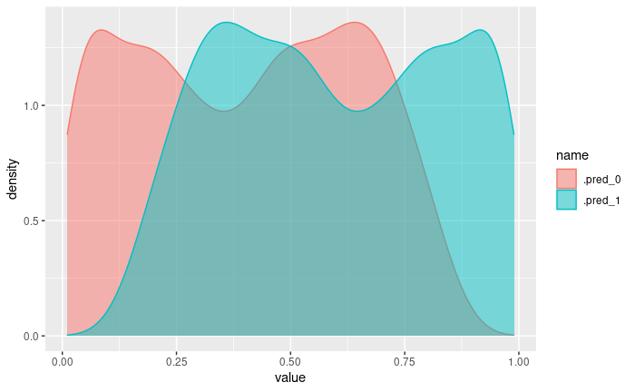

```r
predichos_final2 %>%
  pivot_longer(cols = everything()) %>%
  ggplot(aes(x = value, fill = name, color = name)) +
  geom_density(alpha = 0.5)
```

- **Cambiando punto de corte a 0.55:**

```r
predichos_final2 %>%
  mutate(rating = if_else(.pred_1 > 0.55, true = "1", false = "0")) ->
  predichos_probs

# Submission
sampleSub %>%
  select(-rating) %>%
  mutate(rating = predichos_probs$rating) ->
  sub_112_catb_roc_fe1
head(sub_112_catb_roc_fe1)
```

| id | rating |
| --- | --- |
| 5788 | 0 |
| 5789 | 0 |
| 5790 | 0 |
| 5791 | 1 |
| 5792 | 1 |
| 5793 | 0 |

- **Exportando predicciones:**

```r
write_csv(sub_112_catb_roc_fe1, file = "../submission/sub_112_catb_roc_fe1.csv")
```

- **Cambiando punto de corte a 0.45:**

```r
predichos_final2 %>%
  mutate(rating = if_else(.pred_1 > 0.45, true = "1", false = "0")) ->
  predichos_probs2

# Submission
sampleSub %>%
  select(-rating) %>%
  mutate(rating = predichos_probs2$rating) ->
  sub_113_catb_roc_fe1
head(sub_113_catb_roc_fe1)
```

| id | rating |
| --- | --- |
| 5788 | 0 |
| 5789 | 0 |
| 5790 | 0 |
| 5791 | 1 |
| 5792 | 1 |
| 5793 | 0 |

- **Exportando predicciones:**

```r
write_csv(sub_113_catb_roc_fe1, file = "../submission/sub_113_catb_roc_fe1.csv")
```

- **Cambiando punto de corte a 0.40:**

```r
predichos_final2 %>%
  mutate(rating = if_else(.pred_1 > 0.40, true = "1", false = "0")) ->
  predichos_probs3

# Submission
sampleSub %>%
  select(-rating) %>%
  mutate(rating = predichos_probs3$rating) ->
  sub_114_catb_roc_fe1
head(sub_114_catb_roc_fe1)
```

| id | rating |
| --- | --- |
| 5788 | 0 |
| 5789 | 1 |
| 5790 | 1 |
| 5791 | 1 |
| 5792 | 1 |
| 5793 | 0 |

- **Exportando predicciones:**

```r
write_csv(sub_114_catb_roc_fe1, file = "../submission/sub_114_catb_roc_fe1.csv")
```

- **Cambiando punto de corte a 0.47:**

```r
predichos_final2 %>%
  mutate(rating = if_else(.pred_1 > 0.47, true = "1", false = "0")) ->
  predichos_probs4

# Submission
sampleSub %>%
  select(-rating) %>%
  mutate(rating = predichos_probs4$rating) ->
  sub_115_catb_roc_fe1
head(sub_115_catb_roc_fe1)
```

| id | rating |
| --- | --- |
| 5788 | 0 |
| 5789 | 0 |
| 5790 | 0 |
| 5791 | 1 |
| 5792 | 1 |
| 5793 | 0 |

- **Exportando predicciones:**

```r
write_csv(sub_115_catb_roc_fe1, file = "../submission/sub_115_catb_roc_fe1.csv")
```

# Exportando probabilidades

```r
write_csv(predichos_final2, file = "../probabilitys/prob_catb_roc_fe1.csv")
```

# Modelo Final F1

```r
modelo_completo2 <- modelo_final2 %>%
  fit(data = data_final)
```

# Submission

- **Predicciones finales:**

```r
# Predicciones sobre test (submission)
predichos_final_f1 <- modelo_completo2 %>%
  predict(new_data = test_final, type = "class")

# Submission
sampleSub %>%
  select(-rating) %>%
  mutate(rating = predichos_final_f1$.pred_class) ->
  sub_116_catb_f1_fe1
head(sub_116_catb_f1_fe1)
```

| id | rating |
| --- | --- |
| 5788 | 0 |
| 5789 | 0 |
| 5790 | 0 |
| 5791 | 1 |
| 5792 | 1 |
| 5793 | 0 |

- **Exportando predicciones:**

```r
write_csv(sub_116_catb_f1_fe1, file = "../submission/sub_116_catb_f1_fe1.csv")
```

# Probabilidades

```r
# Predicciones sobre test (submission)
predichos_final2_f1 <- modelo_completo2 %>%
  predict(new_data = test_final, type = "prob")
```

- **Distribución de probabilides predichas:**

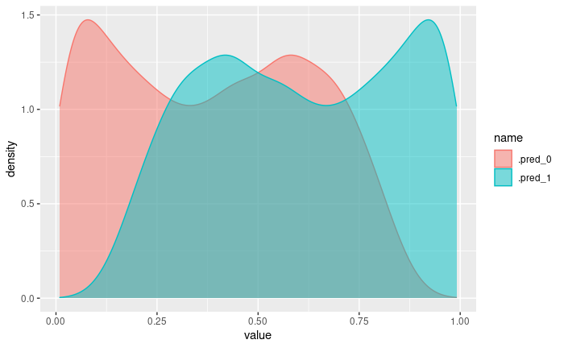

```r
predichos_final2_f1 %>%
  pivot_longer(cols = everything()) %>%
  ggplot(aes(x = value, fill = name, color = name)) +
  geom_density(alpha = 0.5)
```

- **Cambiando punto de corte a 0.55:**

```r
predichos_final2_f1 %>%
  mutate(rating = if_else(.pred_1 > 0.55, true = "1", false = "0")) ->
  predichos_probs_f1

# Submission
sampleSub %>%
  select(-rating) %>%
  mutate(rating = predichos_probs_f1$rating) ->
  sub_117_catb_f1_fe1
head(sub_117_catb_f1_fe1)
```

| id | rating |
| --- | --- |
| 5788 | 0 |
| 5789 | 0 |
| 5790 | 0 |
| 5791 | 1 |
| 5792 | 1 |
| 5793 | 0 |

- **Exportando predicciones:**

```r
write_csv(sub_117_catb_f1_fe1, file = "../submission/sub_117_catb_f1_fe1.csv")
```

- **Cambiando punto de corte a 0.45:**

```r
predichos_final2_f1 %>%
  mutate(rating = if_else(.pred_1 > 0.45, true = "1", false = "0")) ->
  predichos_probs2_f1

# Submission
sampleSub %>%
  select(-rating) %>%
  mutate(rating = predichos_probs2_f1$rating) ->
  sub_118_catb_f1_fe1
head(sub_118_catb_f1_fe1)
```

| id | rating |
| --- | --- |
| 5788 | 0 |
| 5789 | 0 |
| 5790 | 0 |
| 5791 | 1 |
| 5792 | 1 |
| 5793 | 0 |

- **Exportando predicciones:**

```r
write_csv(sub_118_catb_f1_fe1, file = "../submission/sub_118_catb_f1_fe1.csv")
```

- **Cambiando punto de corte a 0.40:**

```r
predichos_final2_f1 %>%
  mutate(rating = if_else(.pred_1 > 0.40, true = "1", false = "0")) ->
  predichos_probs3_f1

# Submission
sampleSub %>%
  select(-rating) %>%
  mutate(rating = predichos_probs3_f1$rating) ->
  sub_119_catb_f1_fe1
head(sub_119_catb_f1_fe1)
```

| id | rating |
| --- | --- |
| 5788 | 1 |
| 5789 | 1 |
| 5790 | 1 |
| 5791 | 1 |
| 5792 | 1 |
| 5793 | 0 |

- **Exportando predicciones:**

```r
write_csv(sub_119_catb_f1_fe1, file = "../submission/sub_119_catb_f1_fe1.csv")
```

- **Cambiando punto de corte a 0.47:**

```r
predichos_final2_f1 %>%
  mutate(rating = if_else(.pred_1 > 0.47, true = "1", false = "0")) ->
  predichos_probs4_f1

# Submission
sampleSub %>%
  select(-rating) %>%
  mutate(rating = predichos_probs4_f1$rating) ->
  sub_120_catb_f1_fe1
head(sub_120_catb_f1_fe1)
```

| id | rating |
| --- | --- |
| 5788 | 0 |
| 5789 | 0 |
| 5790 | 0 |
| 5791 | 1 |
| 5792 | 1 |
| 5793 | 0 |

- **Exportando predicciones:**

```r
write_csv(sub_120_catb_f1_fe1, file = "../submission/sub_120_catb_f1_fe1.csv")
```

# Exportando probabilidades

```r
write_csv(predichos_final2_f1, file = "../probabilitys/prob_catb_f1_fe1.csv")
```